# Biodiversity of Treatment Groups

Mark Watson

April 22, 2025

# Goals

1. Calculate Hill Diversity of samples
2. Evaluate rarefaction curves
3. Evaluate diversity values
4. Make notes of specific samples
5. Plot biodiversity metrics

# Input

1. phytree_physeq

# Output

1. calculated biodiversity measures
2. figures
3. statistical tests

# Scientific Question

How do different mussel community compositions (native, invasive, mixed), affect the bacterial community composition and load of wastewater effluent?

# Setting up the Environment

## Set Seed

```r
set.seed(238428)
```

## Timing Script

```r
start_time <- Sys.time()
start_time
```

```
## [1] "2025-04-22 11:46:26 EDT"
```

## Load Libraries and Phyloseq Object

```r
pacman::p_load(tidyverse, phyloseq, devtools, ggpubr, patchwork, iNEXT,  install = FALSE)

# Load physeq
load("BIOMI4300_Project/data/phytree_preprocessed_physeq.RData")

midpoint_rooted_physeq
```

```
## phyloseq-class experiment-level object
## otu_table()   OTU Table:         [ 4104 taxa and 38 samples ]
## sample_data() Sample Data:       [ 38 samples by 5 sample variables ]
## tax_table()   Taxonomy Table:    [ 4104 taxa by 9 taxonomic ranks ]
## phy_tree()    Phylogenetic Tree: [ 4104 tips and 4103 internal nodes ]
```

```r
metadata_df <-
  midpoint_rooted_physeq %>%
  sample_data() %>%
  data.frame()

# Take a look!
head(metadata_df)
```

```
##                   names mussle_community_composition mussle_community_id
## SRR29551967 SRR29551967                        empty                  C4
## SRR29551968 SRR29551968                      invaded                  C3
## SRR29551969 SRR29551969                      invaded                  C3
## SRR29551970 SRR29551970                      invaded                  C3
## SRR29551971 SRR29551971                     depleted                  C2
## SRR29551972 SRR29551972                     depleted                  C2
##             treatment_id treatment_type
## SRR29551967            A      raw_water
## SRR29551968            A      raw_water
## SRR29551969            A      raw_water
## SRR29551970            A      raw_water
## SRR29551971            A      raw_water
## SRR29551972            A      raw_water
```

```r
# Load in colors for plotting between different files
source("BIOMI4300_Project/code/colors.R")
```

# BioDiversity Hill Numbers with iNEXT

```r
# prepare input data
iNEXT_input_df <-
  midpoint_rooted_physeq %>%
  otu_table() %>%
  data.frame()

# Quick check
dim(iNEXT_input_df)
```

```
## [1] 4104   38
```

```r
# Run iNEXT: Calculate the Hill Numbers
iNEXT_data <- iNEXT(iNEXT_input_df,
                    q = c(0,1,2),
                    datatype = "abundance",
                    nboot = 20)  # Drop from 50 to 20

  # Save the file
save(iNEXT_data, file = "BIOMI4300_Project/data/iNEXT_data.RData")
```

# Evaluate the Diversity

```r
# Prepare Colors
color_df <-
  iNEXT_input_df %>%
  colnames() %>%
  data.frame()
# Check
head(color_df)
```

```
##             .
## 1 SRR29551967
## 2 SRR29551968
## 3 SRR29551969
## 4 SRR29551970
## 5 SRR29551971
## 6 SRR29551972
```

```r
colnames(color_df)[1] <- "names"
# Check
head(color_df)
```

```
##         names
## 1 SRR29551967
## 2 SRR29551968
## 3 SRR29551969
## 4 SRR29551970
## 5 SRR29551971
## 6 SRR29551972
```

```r
# Make a helper dataframe for plotting with colors
iNEXT_color_df <-
  color_df %>%
  # Merge with metadata
  left_join(metadata_df, by = "names") %>%
  # Merge with colors for plotting with ggiNEXT
  left_join(data.frame(community_colors = community_colors,
            mussle_community_composition = names(community_colors)),
            by = "mussle_community_composition") %>%
  left_join(data.frame(
              treatment_colors = treatment_colors,
              treatment_type = names(treatment_colors)
            ),
            by = "treatment_type")
```

## Plotting and evaluating Diversity

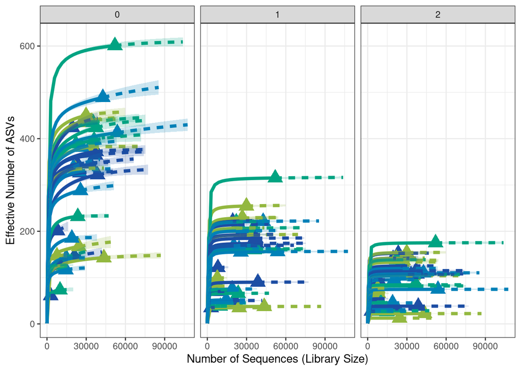

```r
# Plot rarefaction!
# rarefaction/extrapolation curve, type = 1

# Order q:
  # 0 = Richness/ Number of Total taxa
  # 1 = Exponential Shannon / Number of "Common" taxa
  # 2 = Inverse Simpson / Number of "Dominant" taxa

# Community Type
ggiNEXT(iNEXT_data, type = 1, facet.var = "Order.q") +
  facet_wrap(~Order.q, scales = "fixed") +
  scale_color_manual(values = iNEXT_color_df$community_colors, guide = FALSE) +
  scale_fill_manual(values = iNEXT_color_df$community_colors, guide = FALSE) +
  scale_shape_manual(values = base::rep(17, nsamples(midpoint_rooted_physeq)),
                     guide = FALSE) +
  labs(x = "Number of Sequences (Library Size)",
       y = "Effective Number of ASVs") +
  theme_bw() +
  theme(legend.position = "none")
```

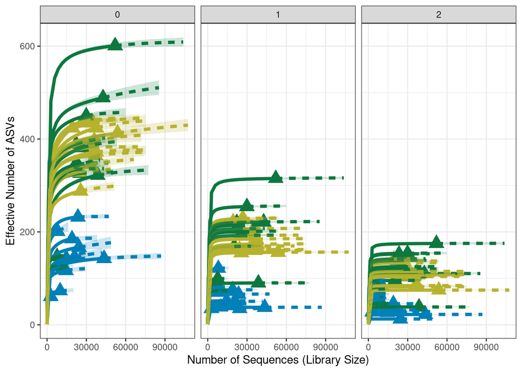

```r
# Treatment Type
ggiNEXT(iNEXT_data, type = 1, facet.var = "Order.q") +
  facet_wrap(~Order.q, scales = "fixed") +
  scale_color_manual(values = iNEXT_color_df$treatment_colors, guide = FALSE) +
  scale_fill_manual(values = iNEXT_color_df$treatment_colors, guide = FALSE) +
  scale_shape_manual(values = base::rep(17, nsamples(midpoint_rooted_physeq)),
                     guide = FALSE) +
  labs(x = "Number of Sequences (Library Size)",
       y = "Effective Number of ASVs") +
  theme_bw() +
  theme(legend.position = "none")
```

## Diversity Analysis Qualitative - 0 = Richness/ Number of Total taxa - 1 = Exponential Shannon / Number of “Common” taxa - 2 = Inverse Simpson / Number of “Dominant” taxa

Richness seems to be the most sensitive to sequencing depth and the data may not be sufficiently sequenced to draw conclusions about richness. Shannon and Simpson seem sufficiently sequenced as seen by the plateau reached.

## Manually Plotting

```r
# Community Plotting
iNEXT_manual_df <-
  iNEXT_data$iNextEst$size_based %>%
  dplyr::rename(names = Assemblage) %>%
  # join with metadata
  left_join(., metadata_df, by = "names") %>%
  # Add colors to data frame
 left_join(data.frame(community_colors = community_colors,
            mussle_community_composition = names(community_colors)),
            by = "mussle_community_composition")
# Inspect
dim(iNEXT_manual_df)
```

```
## [1] 4560   15
```

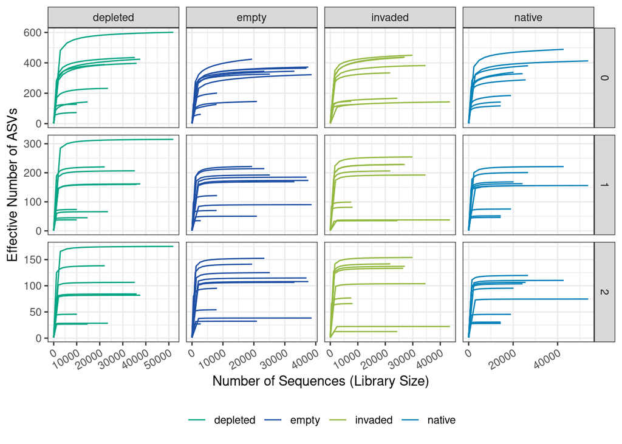

```r
# Plot it - Rarefaction Curve
iNEXT_manual_df %>%
  # Filter out rows that are calcaulted by rarefaction from iNEXT
  dplyr::filter(Method == "Rarefaction") %>%
  # Now, let's draw the plot, be sure to group by the samples if using geom_line!
  ggplot(aes(x = m, y= qD, color = mussle_community_composition, group = names)) +
  geom_line() +
  # Facet with the mussle_community_composition to see the samples better
  facet_grid(Order.q~mussle_community_composition, scales = "free") +
  scale_color_manual(values = community_colors) +
  labs(x = "Number of Sequences (Library Size)",
       y = "Effective Number of ASVs") +
  theme_bw() +
  #guides(color = guide_legend(nrow = 2, byrow = TRUE)) +
  theme(legend.position = "bottom",
        axis.text.x = element_text(angle = 30, vjust = 1, hjust = 1),
        legend.title = element_blank())
```

```r
# Treatment Type
iNEXT_manual_df <-
  iNEXT_data$iNextEst$size_based %>%
  dplyr::rename(names = Assemblage) %>%
  # join with metadata
  left_join(., metadata_df, by = "names") %>%
  # Add colors to data frame
 left_join(data.frame(treatment_colors = treatment_colors,
            treatment_type = names(treatment_colors)),
            by = "treatment_type")
# Inspect
dim(iNEXT_manual_df)
```

```
## [1] 4560   15
```

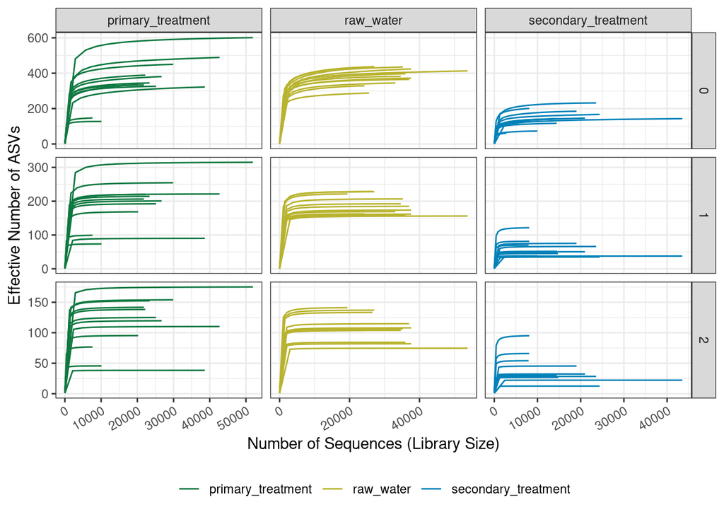

```r
# Plot it - Rarefaction Curve
iNEXT_manual_df %>%
  # Filter out rows that are calcaulted by rarefaction from iNEXT
  dplyr::filter(Method == "Rarefaction") %>%
  # Now, let's draw the plot, be sure to group by the samples if using geom_line!
  ggplot(aes(x = m, y= qD, color = treatment_type, group = names)) +
  geom_line() +
  # Facet with the mussle_community_composition to see the samples better
  facet_grid(Order.q~treatment_type, scales = "free") +
  scale_color_manual(values = treatment_colors) +
  labs(x = "Number of Sequences (Library Size)",
       y = "Effective Number of ASVs") +
  theme_bw() +
  #guides(color = guide_legend(nrow = 2, byrow = TRUE)) +
  theme(legend.position = "bottom",
        axis.text.x = element_text(angle = 30, vjust = 1, hjust = 1),
        legend.title = element_blank())
```

## Community Type There is a large range in Effective Number of ASVs across each variable. Richness in the “empty” and “invaded may not sufficiently plateau, but all others seem okay. Still concerned about the overall spread of the data, but that ma be resolved through normalization of the data.

## Treatment Type

There is more clustering of efffective number of ASVs and a more visually clear pattern of clustering when looking at treatment type ofver looking at the community composition. Looking at it in this way it seems that we do indeed have a beter idea how our data looks.

## Boxplots

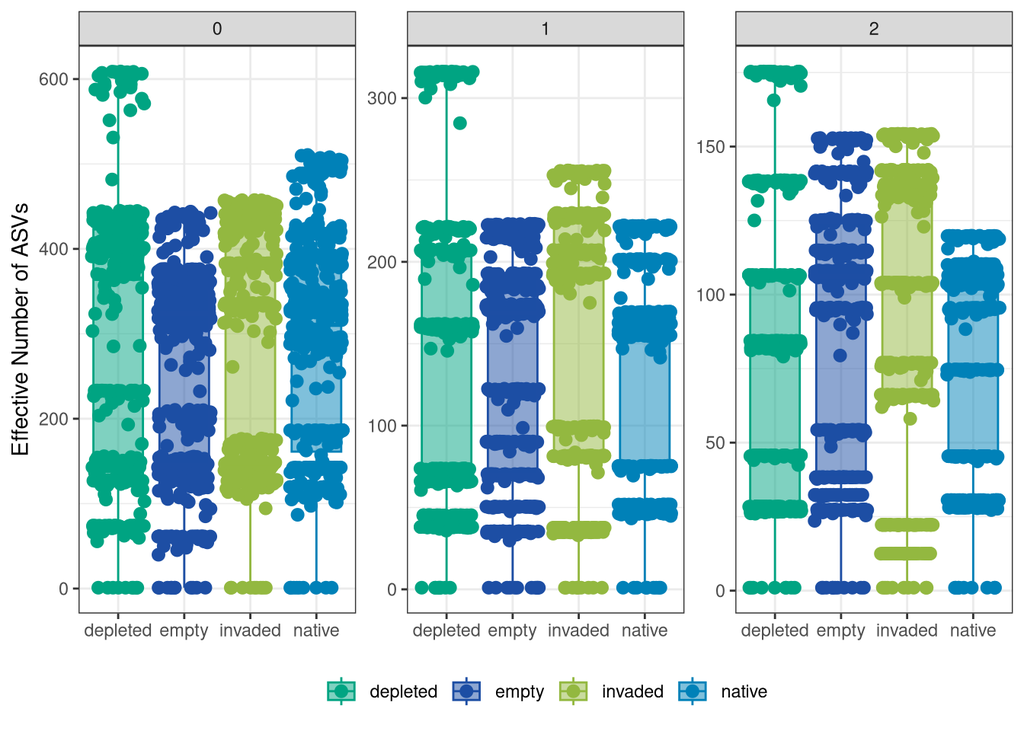

```r
# By community type
iNEXT_manual_df %>%
  ggplot(aes(x = mussle_community_composition, y = qD, fill = mussle_community_composition, color = mussle_community_composition)) +
  facet_wrap(.~Order.q, scales = "free") +
  geom_jitter(size = 2.5) +
  geom_boxplot(alpha = 0.5, outlier.shape = NA) +
  scale_color_manual(values = community_colors) +
  scale_fill_manual(values = community_colors) +
  labs(y = "Effective Number of ASVs") +
  theme_bw() +
  theme(legend.position = "bottom",
        axis.title.x = element_blank(),
        legend.title = element_blank())
```

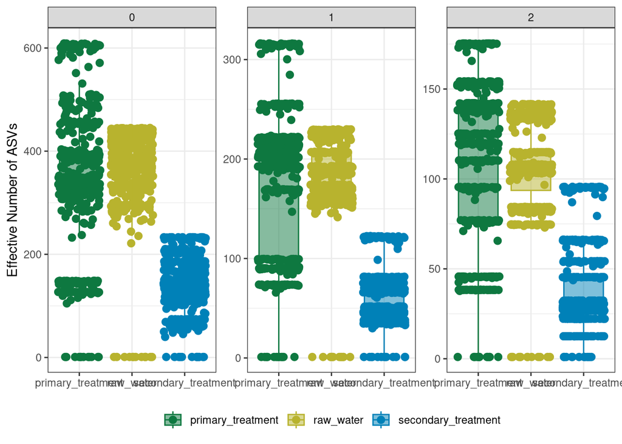

```r
# By treatment type
iNEXT_manual_df %>%
  ggplot(aes(x = treatment_type, y = qD, fill = treatment_type, color = treatment_type)) +
  facet_wrap(.~Order.q, scales = "free") +
  geom_jitter(size = 2.5) +
  geom_boxplot(alpha = 0.5, outlier.shape = NA) +
  scale_color_manual(values = treatment_colors) +
  scale_fill_manual(values = treatment_colors) +
  labs(y = "Effective Number of ASVs") +
  theme_bw() +
  theme(legend.position = "bottom",
        axis.title.x = element_blank(),
        legend.title = element_blank())
```

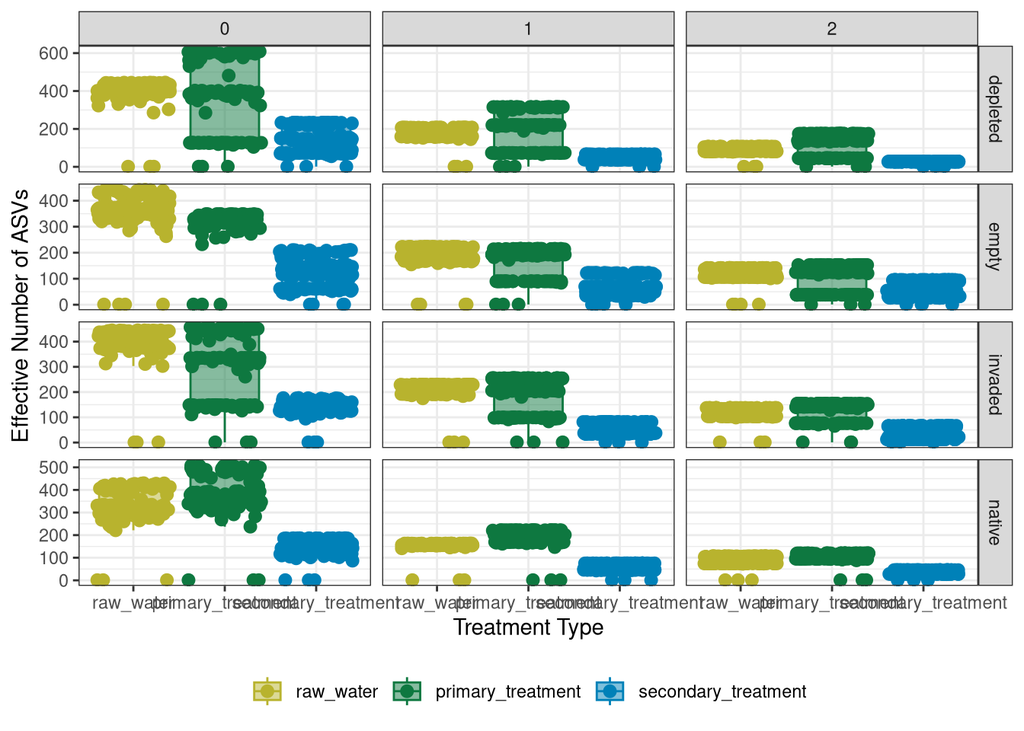

```r
# combined

iNEXT_manual_df$treatment_type <- factor(iNEXT_manual_df$treatment_type,
                                         levels = c("raw_water", "primary_treatment", "secondary_treatment"))

iNEXT_manual_df %>%
  ggplot(aes(x = treatment_type, y = qD, fill = treatment_type, color = treatment_type)) +
  facet_grid(mussle_community_composition ~ Order.q, scales = "free") +
  geom_jitter(size = 2.5) +
  geom_boxplot(alpha = 0.5, outlier.shape = NA) +
  scale_color_manual(values = treatment_colors) +
  scale_fill_manual(values = treatment_colors) +
  labs(y = "Effective Number of ASVs",
       x = "Treatment Type") +
  theme_bw() +
  theme(legend.position = "bottom",
        legend.title = element_blank())
```

Largest differences seem to be richness across treatment types whereas overall the differences across community types seem to be minimal, but will need to have statistical tests to prove these differences.

# Richness Statistical Testing Community

```r
## Make a richness data frame
richness_df_community <-
  iNEXT_manual_df %>%
  dplyr::filter(Method == "Observed") %>%
  dplyr::filter(Order.q == 0)

## Add the statistical test!
kruskal.test(qD ~ mussle_community_composition, data = richness_df_community)
```

```
##
##  Kruskal-Wallis rank sum test
##
## data:  qD by mussle_community_composition
## Kruskal-Wallis chi-squared = 0.75308, df = 3, p-value = 0.8607
```

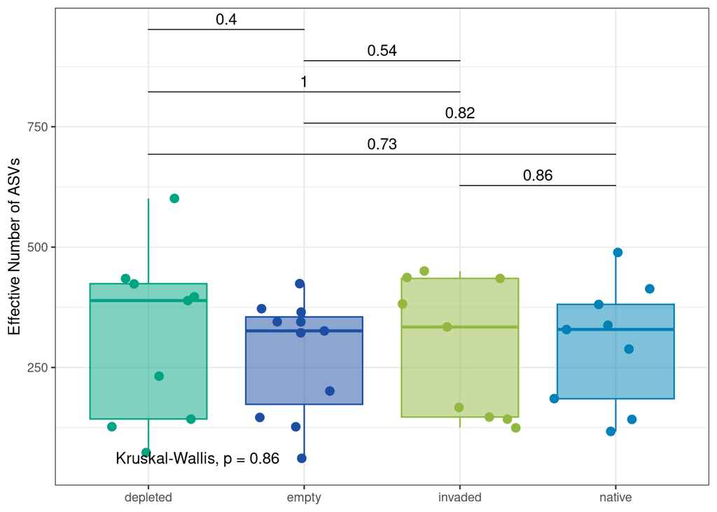

```r
#
community_comparisons_list <- list(
  c("native", "invaded"),
  c("native", "depleted"),
  c("native", "empty"),
  c("invaded", "depleted"),
  c("invaded", "empty"),
  c("depleted", "empty")
)

# Now, plot it!
richness_df_community %>%
  ggplot(aes(x = mussle_community_composition, y = qD, fill = mussle_community_composition, color = mussle_community_composition)) +
  geom_jitter(size = 2.5) +
  geom_boxplot(alpha = 0.5, outlier.shape = NA) +
  scale_color_manual(values = community_colors) +
  scale_fill_manual(values = community_colors) +
  labs(y = "Effective Number of ASVs") +
  # Add pairwise comparisons p-value
  stat_compare_means(comparisons = community_comparisons_list,
                     tip.length = 0, hide.ns = TRUE) +
  stat_compare_means(label.y = 50)  +   # Add global p-value
  theme_bw() +
  theme(legend.position = "none",
        axis.title.x = element_blank(),
        legend.title = element_blank())
```

# Richness Statistical Testing Treatment

```r
# Across Treatments
## Make a richness data frame
richness_df_treatment <-
  iNEXT_manual_df %>%
  dplyr::filter(Method == "Observed") %>%
  dplyr::filter(Order.q == 0)

## Add the statistical test!
kruskal.test(qD ~ treatment_type, data = richness_df_treatment)
```

```
##
##  Kruskal-Wallis rank sum test
##
## data:  qD by treatment_type
## Kruskal-Wallis chi-squared = 22.191, df = 2, p-value = 1.518e-05
```

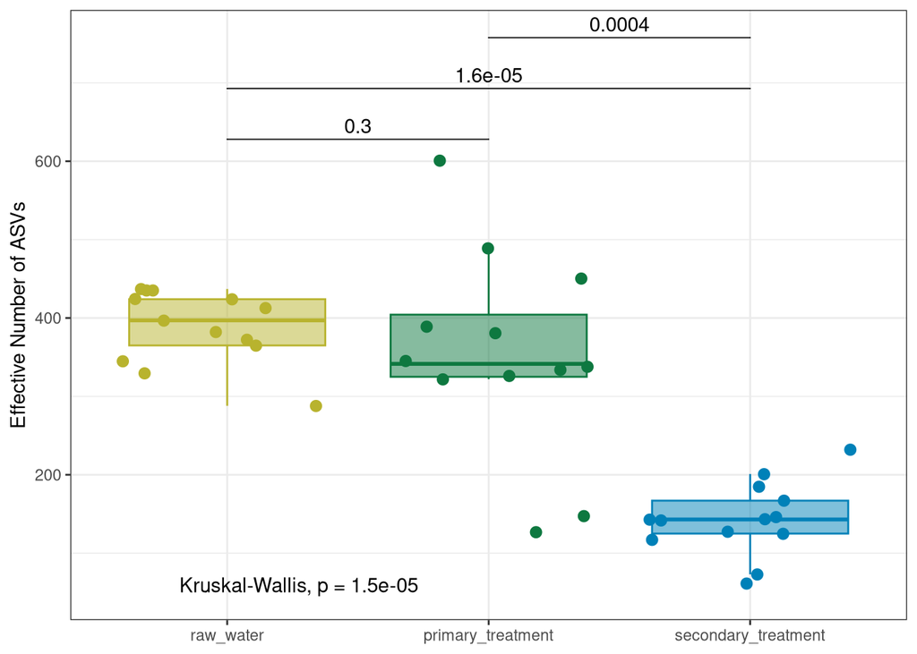

```r
treatment_comparisons_list <- list(
  c("raw_water", "primary_treatment"),
  c("raw_water", "secondary_treatment"),
  c("primary_treatment", "secondary_treatment")
)

# Now, plot it!
richness_df_treatment %>%
  ggplot(aes(x = treatment_type, y = qD, fill = treatment_type, color = treatment_type)) +
  geom_jitter(size = 2.5) +
  geom_boxplot(alpha = 0.5, outlier.shape = NA) +
  scale_color_manual(values = treatment_colors) +
  scale_fill_manual(values = treatment_colors) +
  labs(y = "Effective Number of ASVs") +
  # Add pairwise comparisons p-value
  stat_compare_means(comparisons = treatment_comparisons_list,
                     tip.length = 0, hide.ns = TRUE) +
  stat_compare_means(label.y = 50)  +   # Add global p-value
  theme_bw() +
  theme(legend.position = "none",
        axis.title.x = element_blank(),
        legend.title = element_blank())
```

# Shannon Community Statistical Testing

```r
## Make a richness data frame
shannon_df_community <-
  iNEXT_manual_df %>%
  dplyr::filter(Method == "Observed") %>%
  dplyr::filter(Order.q == 1)

## Add the statistical test!
kruskal.test(qD ~ mussle_community_composition, data = richness_df_community)
```

```
##
##  Kruskal-Wallis rank sum test
##
## data:  qD by mussle_community_composition
## Kruskal-Wallis chi-squared = 0.75308, df = 3, p-value = 0.8607
```

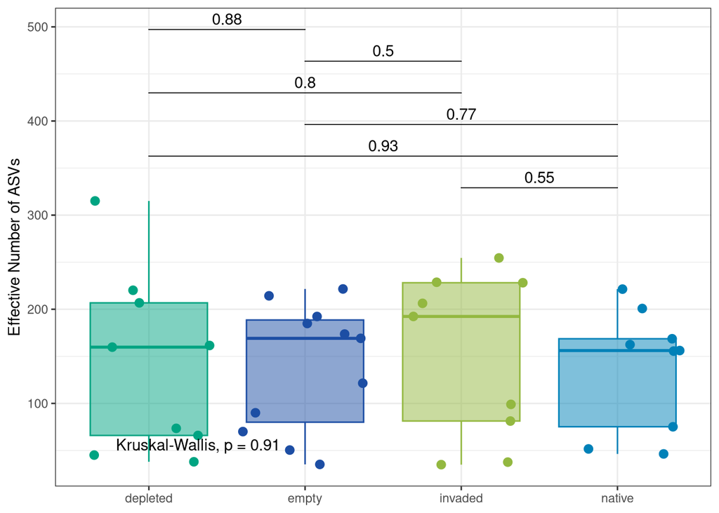

```r
#
community_comparisons_list <- list(
  c("native", "invaded"),
  c("native", "depleted"),
  c("native", "empty"),
  c("invaded", "depleted"),
  c("invaded", "empty"),
  c("depleted", "empty")
)

# Now, plot it!
shannon_df_community %>%
  ggplot(aes(x = mussle_community_composition, y = qD, fill = mussle_community_composition, color = mussle_community_composition)) +
  geom_jitter(size = 2.5) +
  geom_boxplot(alpha = 0.5, outlier.shape = NA) +
  scale_color_manual(values = community_colors) +
  scale_fill_manual(values = community_colors) +
  labs(y = "Effective Number of ASVs") +
  # Add pairwise comparisons p-value
  stat_compare_means(comparisons = community_comparisons_list,
                     tip.length = 0, hide.ns = TRUE) +
  stat_compare_means(label.y = 50)  +   # Add global p-value
  theme_bw() +
  theme(legend.position = "none",
        axis.title.x = element_blank(),
        legend.title = element_blank())
```

# Shannon Statistical Testing Treatment

```r
# Across Treatments
## Make a richness data frame
shannon_df_treatment <-
  iNEXT_manual_df %>%
  dplyr::filter(Method == "Observed") %>%
  dplyr::filter(Order.q == 1)

## Add the statistical test!
kruskal.test(qD ~ treatment_type, data = richness_df_treatment)
```

```
##
##  Kruskal-Wallis rank sum test
##
## data:  qD by treatment_type
## Kruskal-Wallis chi-squared = 22.191, df = 2, p-value = 1.518e-05
```

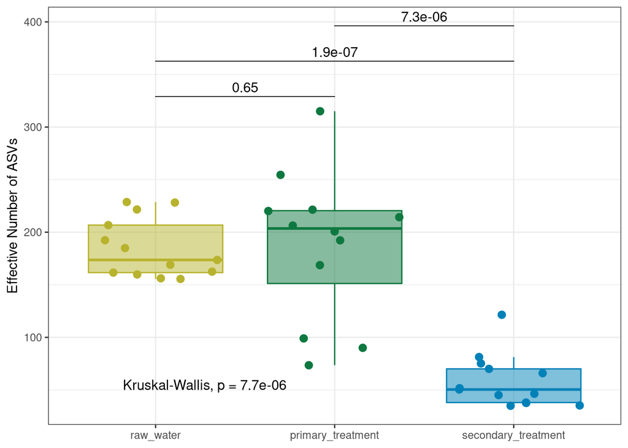

```r
treatment_comparisons_list <- list(
  c("raw_water", "primary_treatment"),
  c("raw_water", "secondary_treatment"),
  c("primary_treatment", "secondary_treatment")
)

# Now, plot it!
shannon_df_treatment %>%
  ggplot(aes(x = treatment_type, y = qD, fill = treatment_type, color = treatment_type)) +
  geom_jitter(size = 2.5) +
  geom_boxplot(alpha = 0.5, outlier.shape = NA) +
  scale_color_manual(values = treatment_colors) +
  scale_fill_manual(values = treatment_colors) +
  labs(y = "Effective Number of ASVs") +
  # Add pairwise comparisons p-value
  stat_compare_means(comparisons = treatment_comparisons_list,
                     tip.length = 0, hide.ns = TRUE) +
  stat_compare_means(label.y = 50)  +   # Add global p-value
  theme_bw() +
  theme(legend.position = "none",
        axis.title.x = element_blank(),
        legend.title = element_blank())
```

# Simpson Community Statistical Testing

```r
## Make a richness data frame
simpson_df_community <-
  iNEXT_manual_df %>%
  dplyr::filter(Method == "Observed") %>%
  dplyr::filter(Order.q == 2)

## Add the statistical test!
kruskal.test(qD ~ mussle_community_composition, data = richness_df_community)
```

```
##
##  Kruskal-Wallis rank sum test
##
## data:  qD by mussle_community_composition
## Kruskal-Wallis chi-squared = 0.75308, df = 3, p-value = 0.8607
```

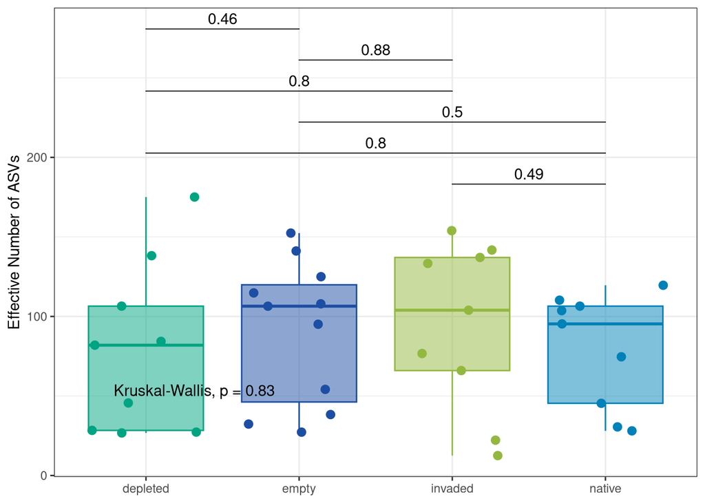

```r
#
community_comparisons_list <- list(
  c("native", "invaded"),
  c("native", "depleted"),
  c("native", "empty"),
  c("invaded", "depleted"),
  c("invaded", "empty"),
  c("depleted", "empty")
)

# Now, plot it!
simpson_df_community %>%
  ggplot(aes(x = mussle_community_composition, y = qD, fill = mussle_community_composition, color = mussle_community_composition)) +
  geom_jitter(size = 2.5) +
  geom_boxplot(alpha = 0.5, outlier.shape = NA) +
  scale_color_manual(values = community_colors) +
  scale_fill_manual(values = community_colors) +
  labs(y = "Effective Number of ASVs") +
  # Add pairwise comparisons p-value
  stat_compare_means(comparisons = community_comparisons_list,
                     tip.length = 0, hide.ns = TRUE) +
  stat_compare_means(label.y = 50)  +   # Add global p-value
  theme_bw() +
  theme(legend.position = "none",
        axis.title.x = element_blank(),
        legend.title = element_blank())
```

# Simpson Statistical Testing Treatment

```r
# Across Treatments
## Make a richness data frame
simpson_df_treatment <-
  iNEXT_manual_df %>%
  dplyr::filter(Method == "Observed") %>%
  dplyr::filter(Order.q == 2)

## Add the statistical test!
kruskal.test(qD ~ treatment_type, data = richness_df_treatment)
```

```
##
##  Kruskal-Wallis rank sum test
##
## data:  qD by treatment_type
## Kruskal-Wallis chi-squared = 22.191, df = 2, p-value = 1.518e-05
```

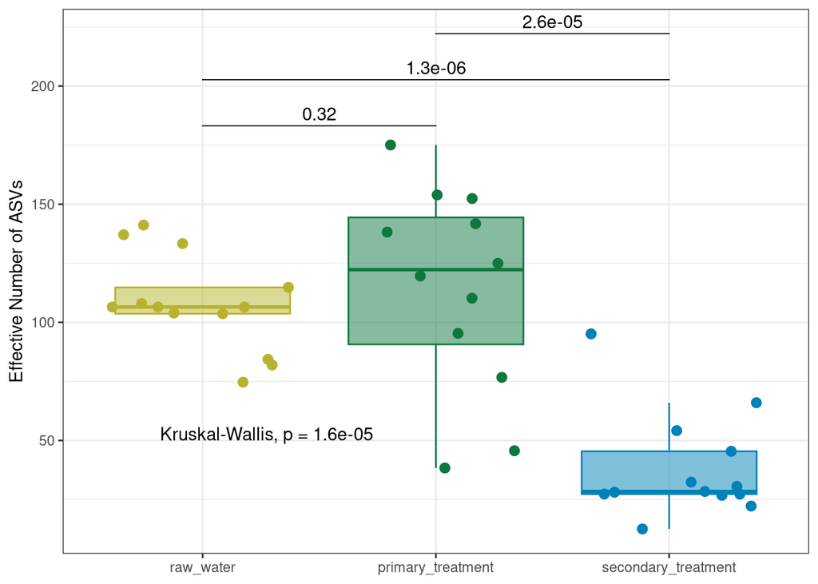

```r
treatment_comparisons_list <- list(
  c("raw_water", "primary_treatment"),
  c("raw_water", "secondary_treatment"),
  c("primary_treatment", "secondary_treatment")
)

# Now, plot it!
simpson_df_treatment %>%
  ggplot(aes(x = treatment_type, y = qD, fill = treatment_type, color = treatment_type)) +
  geom_jitter(size = 2.5) +
  geom_boxplot(alpha = 0.5, outlier.shape = NA) +
  scale_color_manual(values = treatment_colors) +
  scale_fill_manual(values = treatment_colors) +
  labs(y = "Effective Number of ASVs") +
  # Add pairwise comparisons p-value
  stat_compare_means(comparisons = treatment_comparisons_list,
                     tip.length = 0, hide.ns = TRUE) +
  stat_compare_means(label.y = 50)  +   # Add global p-value
  theme_bw() +
  theme(legend.position = "none",
        axis.title.x = element_blank(),
        legend.title = element_blank())
```

It appears that Richness, simpson, and shannon are all not significantly affected by community type. Only treatment type (independant variable) from raw/primary treatment to secondary treatment has an impact on biodiversity.

# Final Info for Reproducibility

```r
end_time <- Sys.time()
end_time
```

```
## [1] "2025-04-22 11:54:35 EDT"
```

```r
elapsed_time <- round((end_time - start_time), 3)
elapsed_time
```

```
## Time difference of 8.151 mins
```